# Mon Site Web

[figure not shown]

## Baptiste Gorteau

Diplômé [master MAS](https://sites-formations.univ-rennes2.fr/master-mas/) (mathématiques appliqués aux statistiques)  
📍 [Université Rennes 2](https://www.univ-rennes2.fr/)

## Réseaux

# programming PCA

# 1 Introduction

The aim of this project is to program a function for performing a PCA on data. First, we’ll program a function to calculate the coordinates of the axes and individuals, then, in a second phase, we’ll program a function to represent the axes and individuals according to their coordinates. Once these two steps have been completed, we’ll program a function to calculate the coordinates of additional individuals in our dataset.

# 2 data importation

To test our functions throughout this work, we’ll use the [alcohol dataset](https://search.r-project.org/CRAN/refmans/fdm2id/html/alcohol.html).

```r
alcool <- read.csv("alcool.csv",sep=";",header = TRUE, row.names = 1)
alcool
```

```
##         vin biere alcool esperance cardio
## France 63.5  40.1    2.5        78   61.1
## Italy  58.0  25.1    0.9        78   94.1
## Suisse 46.0  65.0    1.7        78  106.4
## Austra 15.7 102.1    1.2        78  173.0
## Brit   12.2 100.0    1.5        77  199.7
## U.S.A.  8.9  87.8    2.0        76  176.0
## Russie  2.7  17.1    3.8        69  373.6
## Czech   1.7 140.0    1.0        73  283.7
## Japan   1.0  55.0    2.1        79   34.7
## Mexico  0.2  50.4    0.8        73   36.4
```

# 3 Program a **cr** function that centers and reduces an array of data.

The first step is to calculate the standard deviation of each variable in the input dataset.

The standard deviation of a variable $X$ is compute by the following formula :

$$\sigma(X) =
\sqrt{\frac{1}{n}\sum_{i=1}^{n}(x_i - \bar{X})^2}$$

```r
ecartype <- function(x){
  sqrt(mean((x-mean(x))^2))
}
```

When standard deviation is computed, we can center and reduce our data with the followig formula :

$$X' = \frac{X -
\bar{X}}{\sigma(X)}$$

```r
cr <- function(matrice){
  n <- nrow(matrice)
  moy <- apply(matrice, FUN = mean, MARGIN = 2)
  moy <- matrix(rep(moy, n), nrow = n, byrow = T)

  e_type <- apply(matrice, FUN = ecartype, MARGIN = 2)
  e_type <- matrix(rep(e_type,n), nrow = n, byrow = T)
  return((matrice-moy)/e_type)
}
```

Here’s what our data look like once they’ve been centered and reduced :

```r
print(cr(alcool))
```

```
##               vin       biere      alcool   esperance     cardio
## France  1.7976263 -0.76756852  0.86573687  0.68898765 -0.8824200
## Italy   1.5650470 -1.17642959 -0.98116846  0.68898765 -0.5685269
## Suisse  1.0576013 -0.08885914 -0.05771579  0.68898765 -0.4515304
## Austra -0.2236990  0.92239058 -0.63487371  0.68898765  0.1819629
## Brit   -0.3717040  0.86515003 -0.28857896  0.36089829  0.4359309
## U.S.A. -0.5112515  0.53260969  0.28857896  0.03280894  0.2104986
## Russie -0.7734318 -1.39448883  2.36634745 -2.26381657  2.0900522
## Czech  -0.8157189  1.95544622 -0.86573687 -0.95145914  1.2349314
## Japan  -0.8453199 -0.36143319  0.40401054  1.01707701 -1.1335344
## Mexico -0.8791496 -0.48681725 -1.09660004 -0.95145914 -1.1173642
```

# 4 Program an **acp** function to perform PCA calculations

Our function need to return :

- Axis-by-axis inertia calculation
- Axis coordinates of variables (for 3 axes)
- Coordinates of individuals on axes (for 3 axes)

The first step in our function is to calculate the covariance and correlation matrix of our data :

- **Covariance** :
  $$\text{Cov}(X, Y) = \frac{1}{n} \sum_{i=1}^{n}
  (X_i - \bar{X})(Y_i - \bar{Y})$$
  $$\Sigma = \begin{bmatrix}
  \text{Cov}(X_1, X_1) & \text{Cov}(X_1, X_2) & \cdots &
  \text{Cov}(X_1, X_n) \\
  \text{Cov}(X_2, X_1) & \text{Cov}(X_2, X_2) & \cdots &
  \text{Cov}(X_2, X_n) \\
  \vdots & \vdots & \ddots & \vdots \\
  \text{Cov}(X_n, X_1) & \text{Cov}(X_n, X_2) & \cdots &
  \text{Cov}(X_n, X_n)
  \end{bmatrix}$$
- **Correlation** :
  $$\rho(X,
  Y) = \frac{\text{Cov}(X, Y)}{\sigma_X \sigma_Y}$$
  $$R = \begin{bmatrix}
  1 & \rho(X_1, X_2) & \cdots & \rho(X_1, X_n) \\
  \rho(X_2, X_1) & 1 & \cdots & \rho(X_2, X_n) \\
  \vdots & \vdots & \ddots & \vdots \\
  \rho(X_n, X_1) & \rho(X_n, X_2) & \cdots & 1
  \end{bmatrix}$$

Once these two matrix have been calculated, the inertia of each axis is calculated from the eigenvalues of the covariance matrix.

- **eigenvalues** : The eigenvalues are determined by solving the following system :
  $$\det(X -
  \lambda I) = 0$$
  with $X$ the data, $\lambda$ the eigenvalues and $I$ the identity matrix.
- **inertia** :
  $$\text{In} =
  \frac{\lambda}{\sum_{j=1}^{p} \lambda_j}\times 100$$
  with $\lambda = (\lambda_{1}...\lambda_{n})$

We then calculate the coordinates of the variables on the axes, always using the eigenvalues but also the eigenvectors.

- **eigenvectors** : The eigenvectors are determined by solving the following system :
  $$X \cdot v_j
  = \lambda_j \cdot v_j$$
  with $X$ the data, $v_j$ the eigenvector you are looking for and $\lambda_j$ the eigenvalue corresponding to the eigenvector $v_j$.
- **coordinates of the variables on the axes** :
  $$\text{Coor}_j =
  \sqrt{\lambda_j}*v_j$$

We can now calculate the coordinates of the individuals on the axes. The coordinates of the axis $i$ is calculate by the following formula :
$$\text{Coord-ind}_i = \sum_{j = 1}^{p}X'_j
\times v_{j,i}$$

```r
acp <- function(tablecr){
  mat_cor <- cor(tablecr)
  mat_cov <- cov(tablecr)
  # Calculating inertia
  inertie <- (eigen(mat_cov)$values/sum(eigen(mat_cov)$values))*100
  inertie <- t(as.matrix(inertie))
  colnames(inertie) <- c(1:length(inertie))
  row.names(inertie) <- "Axis inertia (in %)"
  # Variable coordinates
  mat_eig <- eigen(mat_cor)
  mat_val_propres <- NULL
  for(j in 1:ncol(tablecr)){
    rf <- sqrt(mat_eig$values[j])*mat_eig$vectors[,j]
    mat_val_propres <- cbind(mat_val_propres,rf)
  }
  row.names(mat_val_propres) <- colnames(tablecr)
  coord_var <- mat_val_propres[,1:3]
  colnames(coord_var) <- c("axis1","axis2","axis3")
  # Coordinates of individuals on axes
  axe1 <- 0
  axe2 <- 0
  axe3 <- 0
  for (i in 1:ncol(tablecr)){
    axe1 <- axe1+tablecr[,i]*eigen(mat_cor)$vectors[i,1]
    axe2 <- axe2+tablecr[,i]*eigen(mat_cor)$vectors[i,2]
    axe3 <- axe3+tablecr[,i]*eigen(mat_cor)$vectors[i,3]
  }
  coord_indiv <- data.frame(axe1,axe2,axe3)
  row.names(coord_indiv) <- rownames(tablecr)
  return(list("inertia" =inertie ,"var"=coord_var,"indiv"=coord_indiv))
}
```

Applying the function to our data :

- **Inertia** :

```r
acp(cr(alcool))$inertia
```

```
##                           1        2        3        4        5
## Axis inertia (in %) 46.0276 32.11477 11.68471 8.444269 1.728655
```

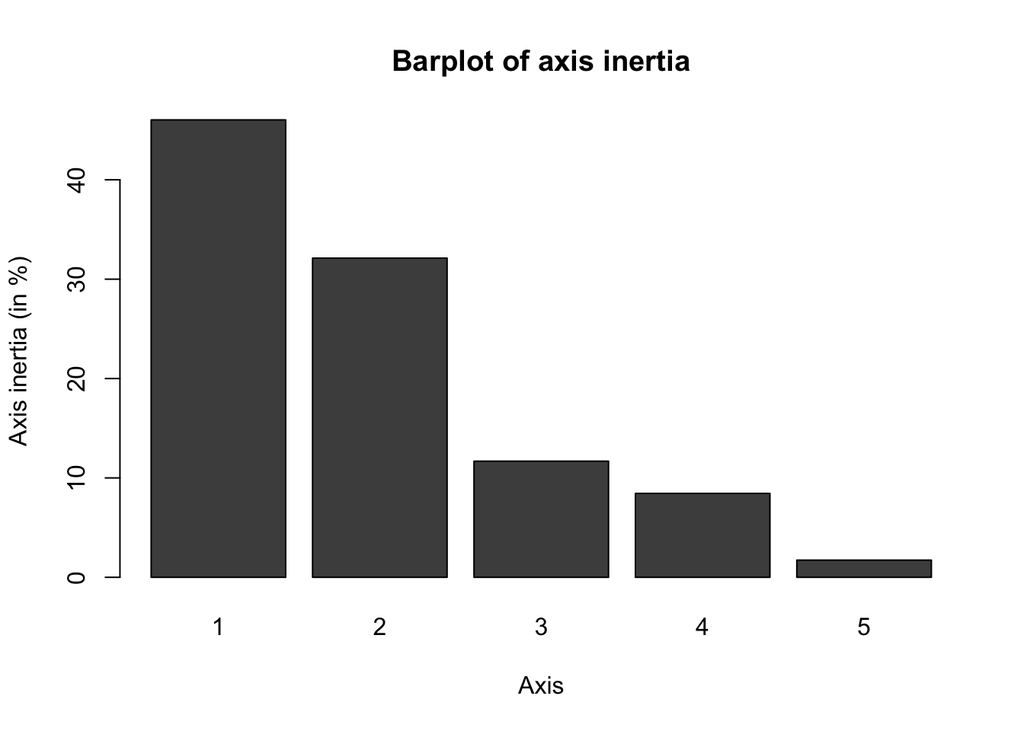

```r
barplot(acp(cr(alcool))$inertia, xlab="Axis", ylab = "Axis inertia (in %)", main = "Barplot of axis inertia")
```

- **Variable coordinates** :

```r
acp(cr(alcool))$var
```

```
##                axis1       axis2     axis3
## vin        0.6751382  0.47945316 0.4721512
## biere     -0.1122014 -0.91794937 0.3246820
## alcool    -0.5247353  0.71987322 0.1638705
## esperance  0.8874321 -0.10951324 0.2059378
## cardio    -0.8775514 -0.05496668 0.4320029
```

- **Coordinates of individuals on axes** :

```r
acp(cr(alcool))$indiv
```

```
##              axe1       axe2         axe3
## France  1.4708242  1.7067366  0.656875833
## Italy   1.8548184  0.8520902  0.120980839
## Suisse  1.1614494  0.3917812  0.533608175
## Austra  0.3496090 -1.1809277  0.405995568
## Brit   -0.1706453 -0.9813967  0.419641992
## U.S.A. -0.4693119 -0.4272907  0.100114671
## Russie -3.5928936  2.1668244  0.008550232
## Czech  -1.4791502 -2.1883308  0.582766542
## Japan   0.7614671  0.1327720 -0.955709910
## Mexico  0.1138329 -0.4722585 -1.872823942
```

# 5 Program a **plotacp** function to produce PCA graphs

The plotacp function allows us to visualize individuals and variables according to their coordinates on two selected axes.

```r
plotacp <- function(X,axe1,axe2,type){
  if(type=="ind"){
    plot(X$indiv[,axe1],X$indiv[,axe2],pch=20,main="PCA graph for individuals",xlab="",ylab="",xlim=c(min(X$ind[,axe1])-0.5,max(X$ind[,axe1])+0.5),ylim=c(min(X$ind[,axe2])-0.5,max(X$ind[,axe2])+0.5))
    title(xlab = paste("Dim",axe1,"(",round(X$inertia[1,axe1],2),"%)"),ylab =paste("Dim",axe2,"(",round(X$inertia[1,axe2],2),"%)"),adj=1,line=2.2)
    grid(NULL,NULL,lty=2,lwd=1)
    abline(h=0)
    abline(v=0)
    text(X$indiv[,axe1],X$indiv[,axe2],labels=row.names(X$indiv),cex=0.9,pos=1)
  }
  if(type=="var"){
    plot(X$var[,axe1],X$var[,axe2],xlim=c(-1,1),ylim=c(-1,1),type="n",main="PCA graph for variables",xlab="",ylab="")
    title(xlab = paste("Dim",axe1,"(",round(X$inertia[1,axe1],2),"%)"),ylab =paste("Dim",axe2,"(",round(X$inertia[1,axe2],2),"%)"),adj=1,line=2.2)
    grid(NULL,NULL,lty=2,lwd=1)
    segments(-1,0,1,0,lty=2)
    segments(0,-1,0,1,lty=2)
    draw.circle(0,0,1)
    text(X$var[,axe1],X$var[,axe2],labels=row.names(X$var),cex=0.9,pos=1)
    for(i in 1:nrow(X$var)){
      arrows(0,0,X$var[i,axe1],X$var[i,axe2],length = 0.1)
    }
  }
}
```

- **Individuals** :

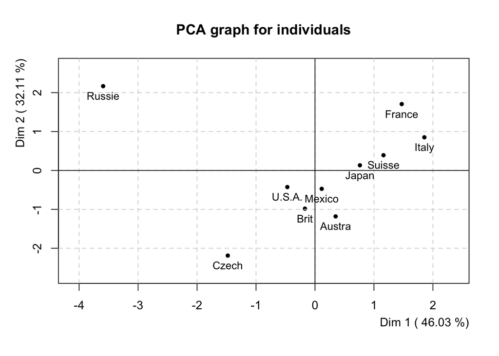

```r
plotacp(acp(cr(alcool)),1,2,"ind")
```

- **Variables** :

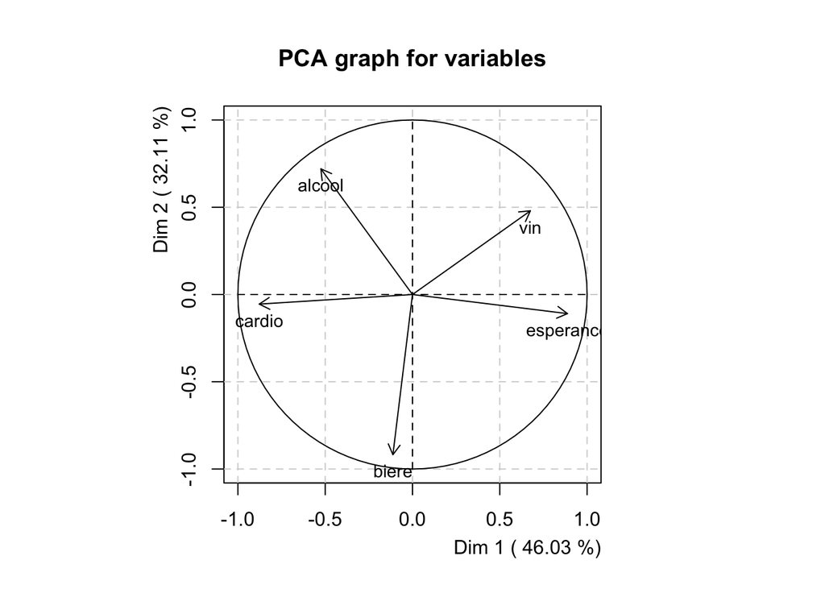

```r
par(pin = c(3.2, 3.2))
plotacp(acp(cr(alcool)),1,2,"var")
```

# 6 Program an **indsup** function to calculate the coordinates of additional individuals (for 3 axes)

In this section, we build on the previous steps. - We determine which individuals in our dataset are additional individuals. - We center and reduce the additional individuals from the data from which we subtract the additional individuals. - We calculate the coordinates of the extra individuals on the axes from the eigenvectors of the data without the extra individuals.

```r
indsup <- function(data_frame,ind_sup){
  table_ind_sup <- data_frame[ind_sup,]
  n <- nrow(table_ind_sup)
  data_frame_2 <- data_frame[-ind_sup,]
  moy_table <- apply(data_frame_2,FUN=mean,MARGIN = 2)
  moy_table <-  matrix(rep(moy_table, n), nrow = n, byrow = T)
  ec_type_table <- apply(data_frame_2,FUN=ecartype, MARGIN = 2)
  ec_type_table <- matrix(rep(ec_type_table,n), nrow = n, byrow = T)
  ind_sup_cr <- (table_ind_sup-moy_table)/ec_type_table
  axe1 <- 0
  axe2 <- 0
  axe3 <- 0
  mat_vect_propre <- eigen(cov(cr(data_frame_2)))$vectors
  for (i in 1:ncol(table_ind_sup)){
    axe1 <- axe1+ind_sup_cr[,i]*mat_vect_propre[i,1]
    axe2 <- axe2+ind_sup_cr[,i]*mat_vect_propre[i,2]
    axe3 <- axe3+ind_sup_cr[,i]*mat_vect_propre[i,3]
  }
  coord_indiv <- data.frame(axe1,axe2,axe3)
  row.names(coord_indiv) <- row.names(data_frame[ind_sup,])
  return(coord_indiv)
}
```

Here’s an example :

```r
indsup(alcool,c(1,2))
```

```
##             axe1     axe2     axe3
## France -1.148603 3.240450 2.046132
## Italy  -1.708153 2.551218 1.440058
```